# Transportation Fatalities

Gabriel Hooks

```r
library(maps)
```

```r
knitr::opts_chunk$set(echo = TRUE, fig.width = 10, fig.height = 5, fig.align = "center")
```

```r
install.packages("extrafont")
library(extrafont)
font_import()
loadfonts(device = "win")
```

```r
data <- read.csv("data/accident2019.csv", sep = ';', row.names = NULL)
```

```r
# Remove unneeded columns
df_clean <- data[, -c(1, 11, 13, 16, 18, 20, 23, 25, 27, 32, 34, 36, 39, 41, 43,
                      44, 46, 48, 50, 52, 54, 57, 58, 60, 62, 64, 66, 69, 70, 73,
                      75, 77, 79, 81, 83, 84, 86, 88)]

# Aggregate date columns into one Data variable, remove redundant year, month, date columns
df_clean <- add_column(df_clean, DATE = as.Date(with(df_clean, paste(YEAR, MONTH, DAY, sep="-")), "%Y-%m-%d"), .after = "CITYNAME")
df_clean <- df_clean[, -c(13, 14, 15)]

# Remove "(id)" after county name in COUNTYNAME
df_clean$COUNTYNAME <- gsub("\\(\\d+\\)", "", df_clean$COUNTYNAME)

# Any HOUR or MINUTE column may have values greater than 24 or 60, which represents
# unknown or NA. Replace with NA
df_clean$HOUR <- ifelse(df_clean$HOUR > 24, NA, df_clean$HOUR)
df_clean$MINUTE <- ifelse(df_clean$MINUTE > 60, NA, df_clean$MINUTE)

df_clean$NOT_HOUR <- ifelse(df_clean$NOT_HOUR > 24, NA, df_clean$NOT_HOUR)
df_clean$NOT_MIN <- ifelse(df_clean$NOT_MIN > 60, NA, df_clean$NOT_MIN)

df_clean$ARR_HOUR <- ifelse(df_clean$ARR_HOUR > 24, NA, df_clean$ARR_HOUR)
df_clean$ARR_MIN <- ifelse(df_clean$ARR_MIN > 60, NA, df_clean$ARR_MIN)

df_clean$HOSP_HR <- ifelse(df_clean$HOSP_HR > 24, NA, df_clean$HOSP_HR)
df_clean$HOSP_MN <- ifelse(df_clean$HOSP_MN > 60, NA, df_clean$HOSP_MN)
```

## Removed Columns (Numbers and Names)

1, 11, 13, 16, 18, 20, 23, 25, 27, 32, 34, 36, 39, 41, 43, 44, 46, 48, 50, 52, 54, 57, 58, 60, 62, 64, 66, 69, 70, 73, 75, 77, 79, 81, 83, 84, 86, 88

STATE, COUNTY, CITY, DAYNAME, MONTHNAME, DAY_WEEK, HOURNAME, MINUTENAME, NHSNAME, RUR_URB, FUNC_SYS, RD_OWNER, MILEPTNAME, LATITUDENAME, LONGITUDENAME, SP_JUR, HARM_EV, MAN_COLL, RELJCT1, RELJCT2, TYP_INT, WRK_ZONENAME, REL_ROAD, LGT_COND, WEATHER1, WEATHER2, WEATHER, SCH_BUSNAME, RAIL, NOT_HOURNAME, NOT_MINNAME, ARR_HOURNAME, HOSP_HRNAME, HOSP_MNNAME, CF1, CF2, CF3

These were removed because these are either redundant or numerical codes representing information about the incident. These columns were probably intended to be used following a specific convention for database that the DOT uses.

Fortunately, all columns with numeric codes have another column explaining what that code means. There are also a few documents that have some information on the terms and abbreviations.

https://cdan.nhtsa.gov/Homepage/Terms&Acronyms.pdf https://www.tn.gov/content/dam/tn/tdot/long-range-planning/research/final-reports/res2016-final-reports/RES2016-34%20Final%20Report%20Revised%20-%20Approved.pdf

```r
df_melt <- melt(df_clean, id=c("STATENAME"), value.name = "FATALS")
```

```r
plot_states <- ggplot(df_clean, aes(x = fct_infreq(STATENAME), fill = -..count.., color = -..count..)) +
  geom_bar(stat = 'count', width = 0.7) +
  coord_flip(ylim = c(1, 3500)) +
  labs(title = "Number of Accidents by State",
       x = "State") +
  dark_theme_gray() +
  theme(axis.text.y = element_text(size = 7),
        axis.title = element_blank(),
        legend.position = "none") +
  scale_fill_distiller(palette = "RdPu") +
  scale_color_distiller(palette = "RdPu")
plot_states


# Only greater than one fatality
plot_multiple <- ggplot(subset(df_clean, FATALS > 1), aes(x = fct_infreq(STATENAME), fill = -..count.., color = -..count..)) +
  geom_bar(stat = 'count', width = 0.7) +
  #coord_fixed(xlim = NULL, ylim = c(1, 4000), default = TRUE) +
  coord_flip(ylim = c(1, 1000)) +
  labs(title = "Number of Accidents with More than One Fatality",
       x = "State") +
  dark_theme_gray() +
  theme(axis.text.y = element_text(size = 7),
        axis.title = element_blank(),
        legend.position = "none") +
  scale_fill_distiller(palette = "RdPu") +
  scale_color_distiller(palette = "RdPu")
plot_multiple
```

```r
# Same as above but for only drunk driving related accidents
plot_dui <- ggplot(subset(df_clean, DRUNK_DR != 0), aes(x = fct_infreq(STATENAME), fill = -..count.., color = -..count..)) +
  geom_bar(stat = 'count', width = 0.7) +
  coord_flip(ylim = c(1, 3500)) +
  labs(title = "Number of DUI-Related Accidents by State",
       x = "State") +
  dark_theme_gray() +
  theme(axis.text.y = element_text(size = 7),
        axis.title = element_blank(),
        legend.position = "none") +
  scale_fill_distiller(palette = "RdPu") +
  scale_color_distiller(palette = "RdPu")
plot_dui


# Only greater than one fatality while DUI
plot_multiple_dui <- ggplot(subset(df_clean, DRUNK_DR != 0 & FATALS > 1), aes(x = fct_infreq(STATENAME), fill = -..count.., color = -..count..)) +
  geom_bar(stat = 'count', width = 0.7) +
  #coord_fixed(xlim = NULL, ylim = c(1, 4000), default = TRUE) +
  coord_flip(ylim = c(1, 250)) +
  labs(title = "Number of DUI-Related Accidents with More than One Fatality",
       x = "State") +
  dark_theme_gray() +
  theme(text = element_text(family = "Gotham"),
        axis.text.y = element_text(size = 7),
        axis.title = element_blank(),
        legend.position = "none") +
  scale_fill_distiller(palette = "RdPu") +
  scale_color_distiller(palette = "RdPu")
plot_multiple_dui
```

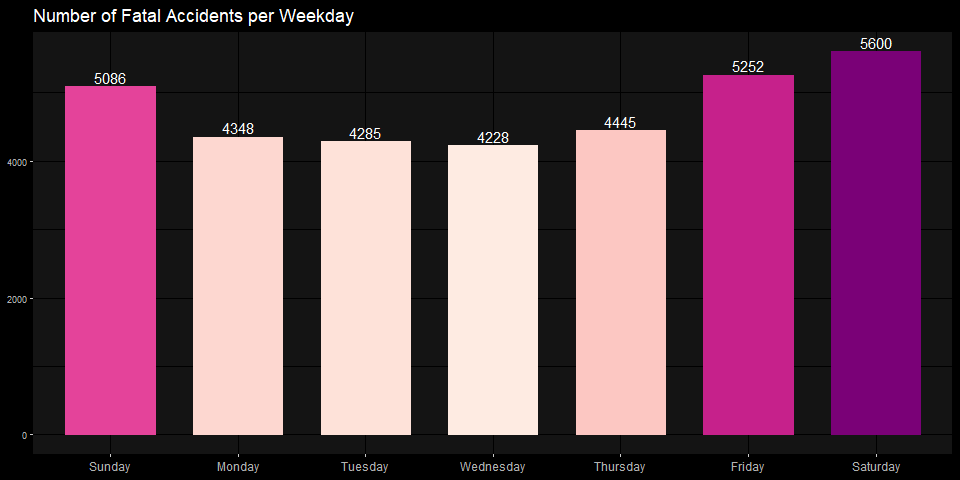

```r
plot_weekday <- ggplot(df_clean, aes(x = factor(DAY_WEEKNAME,
                                levels = c("Sunday", "Monday", "Tuesday",
                                           "Wednesday", "Thursday",
                                           "Friday", "Saturday")),
                     fill = -..count..,
                     color = -..count..)) +
  geom_bar(stat = 'count',
           width = 0.7) +
  geom_text(stat = 'count',
            aes(label = ..count..),
            vjust = -0.3,
            color = "white") +
  labs(title = "Number of Fatal Accidents per Weekday",
       x = "") +
  dark_theme_gray() +
  theme(axis.text.y = element_text(size = 7),
        axis.title.y = element_blank(),
        axis.title.x = element_blank(),
        legend.position = "none") +
  scale_fill_distiller(palette = "RdPu") +
  scale_color_distiller(palette = "RdPu")
plot_weekday
```

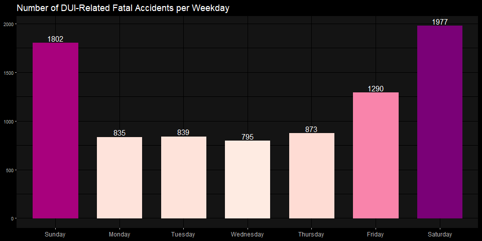

```r
plot_weekday_dui <- ggplot(subset(df_clean, DRUNK_DR != 0), aes(x = factor(DAY_WEEKNAME,
                                levels = c("Sunday", "Monday", "Tuesday",
                                           "Wednesday", "Thursday",
                                           "Friday", "Saturday")),
                     fill = -..count..,
                     color = -..count..)) +
  geom_bar(stat = 'count',
           width = 0.7) +
  geom_text(stat = 'count',
            aes(label = ..count..),
            vjust = -0.3,
            color = "white") +
  labs(title = "Number of DUI-Related Fatal Accidents per Weekday",
       x = "") +
  dark_theme_gray() +
  theme(axis.text.y = element_text(size = 7),
        axis.title.y = element_blank(),
        axis.title.x = element_blank(),
        legend.position = "none") +
  scale_fill_distiller(palette = "RdPu") +
  scale_color_distiller(palette = "RdPu")
plot_weekday_dui
```

```r
plot_rururb <- ggplot(df_clean, aes(x = factor(RUR_URBNAME,
                                levels = c("Rural", "Urban")),
                     fill = -..count..,
                     color = -..count..)) +
  geom_bar(stat = 'count',
           width = 0.7) +
  geom_text(stat = 'count',
            aes(label = scales::percent(prop.table(stat(count)), accuracy = 0.01)),
            vjust = -0.3,
            color = "white") +
  labs(title = "Number of Fatal Accidents in Rural vs. Urban Areas",
       x = "") +
  dark_theme_gray() +
  theme(axis.text.y = element_text(size = 7),
        axis.title.y = element_blank(),
        axis.title.x = element_blank(),
        legend.position = "none") +
  scale_fill_distiller(palette = "RdPu") +
  scale_color_distiller(palette = "RdPu")
plot_rururb
```

```r
plot_weather <- ggplot(subset(df_clean, WEATHER1NAME != ""), aes(x = fct_infreq(WEATHER1NAME),
                     fill = -..count..,
                     color = -..count..)) +
  geom_bar(stat = 'count',
           width = 0.7) +
  geom_text(stat = 'count',
            aes(label = ..count..),
            hjust = -0.15,
            color = "white") +
  coord_flip() +
  labs(title = "Number of Fatal Accidents by Weather Conditions",
       x = "") +
  dark_theme_gray() +
  theme(axis.text.y = element_text(size = 7),
        axis.title.y = element_blank(),
        axis.title.x = element_blank(),
        legend.position = "none") +
  scale_fill_distiller(palette = "RdPu") +
  scale_color_distiller(palette = "RdPu")
plot_weather
```

I want a df with date, total fatalities to date, drunk driving involved y/n

```r
df_count <- df_clean %>%
  group_by(DATE) %>%
  mutate(TOTAL = n()) %>%
  mutate(TOTAL_TO_DATE = sum_run(
    x = TOTAL
  )) %>%
  mutate(DUI = ifelse(DRUNK_DR != 0, "DUI", "Non-DUI"))
```

```r
plot_time <- ggplot(df_count, aes(x = DATE, y = TOTAL, color = as.factor(DUI))) +
  geom_point(alpha = 0.7) +
  scale_color_manual(breaks = c("DUI", "Non-DUI"),
                     values = c("#AE017E", "#FDE0DD")) +
  geom_smooth(se = FALSE,
              alpha = 0.4,
              size = 0.5) +
  labs(title = "Number of Fatal Accidents per Day",
       subtitle = "From 2019-01 to 2020-01",
       x = "",
       y = "") +
  dark_theme_gray() +
  theme(legend.position = "right",
        legend.title = element_blank(),
        axis.title.y = element_blank(),
        axis.title.x = element_blank())
plot_time
```

Get average values for each hour range 0:0-0:59, 1:00-1:59

```r
df_hour <- df_clean %>%
  filter(!is.na(HOUR)) %>%
  mutate(TIME = hms(seconds = NULL, minutes = NULL, hours = HOUR)) %>%
  group_by(HOUR) %>%
  mutate(TOTAL = n()) %>%
  mutate(DUI = ifelse(DRUNK_DR != 0, "DUI", "Non-DUI"))
```

```r
plot_hour_line <- ggplot(df_hour, aes(x = HOUR, y = TOTAL, color = as.factor(DUI))) +
  geom_point(alpha = 0.7) +
  scale_color_manual(breaks = c("DUI", "Non-DUI"),
                     values = c("#AE017E", "#FDE0DD")) +
  geom_smooth(se = FALSE,
              alpha = 0.4,
              size = 0.5) +
 # coord_cartesian(ylim = c(1, 100)) +
  scale_x_continuous("", breaks = seq(0, 23), labels = seq(0, 23)) +
  labs(title = "Average Number of Fatal Accidents per Hour",
       x = "",
       y = "") +
  dark_theme_gray() +
  theme(legend.position = "right",
        legend.title = element_blank(),
        axis.title.y = element_blank(),
        axis.title.x = element_blank())
plot_hour_line
```

```r
plot_hour_polar <- ggplot(df_hour, aes(x = HOUR, color = ..count.., fill = ..count..)) +
  geom_bar(stat = 'count', width = 1) +
  #scale_x_continuous(breaks = seq(0, 360, 30)) +
  coord_polar(theta = "x") +
  scale_x_continuous("", breaks = seq(0, 23), labels = seq(0, 23)) +
  #scale_y_continuous("", limits = c(1, 2000)) +
  labs(title = "Average Number of Fatal Accidents by Hour",
       x = "",
       y = "") +
  dark_theme_gray() +
  scale_color_gradient(low = "#FDE0DD", high = "#AE017E") +
  scale_fill_gradient(low = "#FDE0DD", high = "#AE017E") +
  theme(legend.position = "none",
        legend.title = element_blank(),
        axis.title.y = element_blank(),
        axis.title.x = element_blank())
plot_hour_polar
```

```r
df_states <- df_clean %>%
  group_by(STATENAME) %>%
  summarise(TOTAL = n())

colnames(df_states) <- c("region", "TOTAL")

df_states$region <- sapply(df_states$region, tolower)
```

```r
us_states <- map_data("state")
us_counties <- map_data("county")
```

```r
df_states <- inner_join(us_states, df_states, by = "region")
```

```r
plot_map_usa <- ggplot(df_states, aes(x = long, y = lat, group = group, fill = TOTAL)) +
  geom_polygon(color = "grey6") +
  scale_fill_gradient(low = "#FDE0DD", high = "#AE017E") +
  dark_theme_gray() +
  theme(axis.title = element_blank(),
        axis.text = element_blank(),
        axis.ticks = element_blank())
plot_map_usa
```

```r
us_counties_t <- us_counties
```

```r
df_counties <- df_clean %>%
  mutate(COUNTYNAME = tolower(COUNTYNAME)) %>%
  mutate(COUNTYNAME = trimws(COUNTYNAME, which = "both")) %>%
  group_by(STATENAME, COUNTYNAME) %>%
  summarise(STATENAME = tolower(STATENAME), TOTAL = n())

countyTotals <- function(counties) {
  totals <- c()
  for(i in 1:nrow(counties)) {
    statename <- counties[i, 'region']
    countyname <- counties[i, 'subregion']

    if (countyname %in% df_counties$COUNTYNAME) {
      totals <- append(totals,
                       df_counties[which(df_counties$COUNTYNAME == countyname & df_counties$STATENAME == statename), 'TOTAL'][[1]][1])
    }
    else {
      totals <- append(totals, 0)
      next
    }
  }
  return(totals)
}

county_totals <- countyTotals(us_counties_t)
```

```r
us_counties_t$TOTAL <- county_totals
us_counties_t <- tidyr::unnest(us_counties_t, 7)
```

```r
plot_map_counties <- us_counties_t %>%
  ggplot(aes(x = long, y = lat, group = group, fill = TOTAL)) +
  geom_polygon(size = 0.1) +
  scale_fill_gradient(low = "#FDE0DD", high = "#AE017E") +
  coord_map() +
  labs(title = "Count of Fatal Accidents per US County") +
  dark_theme_gray() +
  theme(axis.title = element_blank(),
        axis.text = element_blank(),
        axis.ticks = element_blank(),
        panel.grid = element_blank())


plot_map_counties
```

```r
fl_counties <- us_counties_t %>%
  filter(region == "florida")
```

```r
plot_map_fl_counties <- fl_counties %>%
  ggplot(aes(x = long, y = lat, group = group, fill = TOTAL)) +
  geom_polygon(size = 0.1) +
  scale_fill_gradient(low = "#FDE0DD", high = "#AE017E") +
  coord_map() +
  labs(title = "Count of Fatal Accidents per Florida County") +
  dark_theme_gray() +
  theme(axis.title = element_blank(),
        axis.text = element_blank(),
        axis.ticks = element_blank(),
        panel.grid = element_blank()) +
  geom_point(aes(y = 28.51, x = -81.32), size = 1, color = "white") +
  geom_text(aes(y = 28.51, x = -81.32),
            label = "#4 Orange",
            color = "white",
            size = 2.9,
            vjust = -0.5,
            hjust = -0.05) +
  geom_point(aes(y = 27.91, x = -82.35), size = 1, color = "white") +
  geom_text(aes(y = 27.91, x = -82.35),
            label = "#2 Hillsborough",
            color = "white",
            size = 2.9,
            vjust = -0.5,
            hjust = -0.05) +
  geom_point(aes(y = 26.71, x = -80.05), size = 1, color = "white") +
  geom_text(aes(y = 26.71, x = -80.05),
            label = "#5 Palm Beach",
            color = "white",
            size = 2.9,
            vjust = -0.6,
            hjust = 1) +
  geom_point(aes(y = 26.124354, x = -80.249503), size = 1, color = "white") +
  geom_text(aes(y = 26.124354, x = -80.249503),
            label = "#3 Broward",
            color = "white",
            size = 2.9,
            vjust = -0.6,
            hjust = 1) +
  geom_point(aes(y = 25.771163582, x = -80.189499242), size = 1, color = "white") +
  geom_text(aes(y = 25.771163582, x = -80.189499242),
            label = "#1 Miami-Dade",
            color = "white",
            size = 2.9,
            vjust = -0.6,
            hjust = 1)

plot_map_fl_counties
```

```r
library(Cairo)
CairoWin()
```

```r
ggsave(plot_dui, filename = "dui.png", dpi = 300, type = "cairo", width = 10, height = 5, units = 'in')
ggsave(plot_hour_line, filename = "hour-line.png", dpi = 300, type = "cairo", width = 10, height = 5, units = 'in')
ggsave(plot_hour_polar, filename = "hour-polar.png", dpi = 300, type = "cairo", width = 10, height = 5, units = 'in')
ggsave(plot_map_counties, filename = "map-counties.png", dpi = 300, type = "cairo", width = 10, height = 5, units = 'in')
ggsave(plot_map_fl_counties, filename = "map-fl-counties.png", dpi = 300, type = "cairo", width = 10, height = 5, units = 'in')
ggsave(plot_map_usa, filename = "map-usa.png", dpi = 300, type = "cairo", width = 10, height = 5, units = 'in')
ggsave(plot_multiple, filename = "multiple-fatal.png", dpi = 300, type = "cairo", width = 10, height = 5, units = 'in')
ggsave(plot_multiple_dui, filename = "multiple-fatal-dui.png", dpi = 300, type = "cairo", width = 10, height = 5, units = 'in')
ggsave(plot_rururb, filename = "rural-urban.png", dpi = 300, type = "cairo", width = 10, height = 5, units = 'in')
ggsave(plot_states, filename = "state-freq.png", dpi = 300, type = "cairo", width = 10, height = 5, units = 'in')
ggsave(plot_time, filename = "time-series.png", dpi = 300, type = "cairo", width = 10, height = 5, units = 'in')
ggsave(plot_weather, filename = "weather.png", dpi = 300, type = "cairo", width = 10, height = 5, units = 'in')
ggsave(plot_weekday, filename = "weekdays.png", dpi = 300, type = "cairo", width = 10, height = 5, units = 'in')
ggsave(plot_weekday_dui, filename = "weekdays_dui.png", dpi = 300, type = "cairo", width = 10, height = 5, units = 'in')
```